# EasyVisa_Full_Code_Solution_Final

### Tuning – Gradient Boosting

```python
gb_param_grid = {
    'init'         : [AdaBoostClassifier(random_state=1), DecisionTreeClassifier(random_state=1)],
    'n_estimators' : np.arange(50, 110, 25),
    'learning_rate': [0.01, 0.1, 0.05],
    'subsample'    : [0.7, 0.9],
    'max_features' : [0.5, 0.7, 1],
}

gb_grid = GridSearchCV(
    GradientBoostingClassifier(random_state=42),
    gb_param_grid, cv=3, scoring='f1', n_jobs=-1, verbose=1, refit=True
)
gb_grid.fit(X_train_over, y_train_over)

gb_tuned = gb_grid.best_estimator_
y_pred_gb = gb_tuned.predict(X_test)

print(f'\nBest GB params : {gb_grid.best_params_}')
print(f'Best CV F1     : {gb_grid.best_score_:.4f}')
print(f'Test Accuracy  : {accuracy_score(y_test, y_pred_gb):.4f}')
print(f'Test F1        : {f1_score(y_test, y_pred_gb):.4f}')
print(f'Test ROC-AUC   : {roc_auc_score(y_test, gb_tuned.predict_proba(X_test)[:,1]):.4f}')
```

```
Fitting 3 folds for each of 108 candidates, totalling 324 fits

Best GB params : {'init': AdaBoostClassifier(random_state=1), 'learning_rate': 0.1, 'max_features': 0.7, 'n_estimators': np.int64(100), 'subsample': 0.9}
Best CV F1     : 0.7964
Test Accuracy  : 0.7345
Test F1        : 0.8073
Test ROC-AUC   : 0.7623
```

### Tuning – AdaBoost

```python
ada_param_grid = {
    'n_estimators' : np.arange(50, 110, 25),
    'learning_rate': [0.01, 0.1, 0.05],
    'estimator'    : [
        DecisionTreeClassifier(max_depth=2, random_state=1),
        DecisionTreeClassifier(max_depth=3, random_state=1),
    ],
}

ada_grid = GridSearchCV(
    AdaBoostClassifier(n_estimators=100, random_state=42),
    ada_param_grid, cv=3, scoring='f1', n_jobs=-1, verbose=1, refit=True
)
ada_grid.fit(X_train_over, y_train_over)

ada_tuned = ada_grid.best_estimator_
y_pred_ada = ada_tuned.predict(X_test)

print(f'\nBest ADA params: {ada_grid.best_params_}')
print(f'Best CV F1     : {ada_grid.best_score_:.4f}')
print(f'Test Accuracy  : {accuracy_score(y_test, y_pred_ada):.4f}')
print(f'Test F1        : {f1_score(y_test, y_pred_ada):.4f}')
print(f'Test ROC-AUC   : {roc_auc_score(y_test, ada_tuned.predict_proba(X_test)[:,1]):.4f}')
```

```
Fitting 3 folds for each of 18 candidates, totalling 54 fits

Best ADA params: {'estimator': DecisionTreeClassifier(max_depth=3, random_state=1), 'learning_rate': 0.1, 'n_estimators': np.int64(100)}
Best CV F1     : 0.7830
Test Accuracy  : 0.7294
Test F1        : 0.8008
Test ROC-AUC   : 0.7551
```

### Tuned Model Performance Summary

```python
tuned_models = {
    'Random Forest (Tuned)'     : rf_tuned,
    'Gradient Boosting (Tuned)' : gb_tuned,
    'AdaBoost (Tuned)'          : ada_tuned,
}

tuned_res = []
for name, model in tuned_models.items():
    y_p  = model.predict(X_test)
    y_pr = model.predict_proba(X_test)[:,1]
    tuned_res.append({'Model':name,
        'Accuracy' : round(accuracy_score(y_test, y_p), 4),
        'Precision': round(precision_score(y_test, y_p, zero_division=0), 4),
        'Recall'   : round(recall_score(y_test, y_p,    zero_division=0), 4),
        'F1 Score' : round(f1_score(y_test, y_p,        zero_division=0), 4),
        'ROC-AUC'  : round(roc_auc_score(y_test, y_pr), 4),
    })

tuned_df = pd.DataFrame(tuned_res).set_index('Model')
tuned_df
```

| Model | Accuracy | Precision | Recall | F1 Score | ROC-AUC |
| --- | --- | --- | --- | --- | --- |
| Random Forest (Tuned) | 0.7345 | 0.7845 | 0.8308 | 0.8070 | 0.7629 |
| Gradient Boosting (Tuned) | 0.7345 | 0.7835 | 0.8325 | 0.8073 | 0.7623 |
| AdaBoost (Tuned) | 0.7294 | 0.7877 | 0.8143 | 0.8008 | 0.7551 |

### 📊 Observations – Tuned Model Performance Summary

| Model | Accuracy | F1 Score | ROC-AUC |
| --- | --- | --- | --- |
| AdaBoost (Tuned) | 0.7294 | 0.8008 | 0.7551 |
| Random Forest (Tuned) | 0.7345 | 0.8070 | 0.7629 |
| **Gradient Boosting (Tuned)** | **0.7345** | **0.8073** | **0.7623** |

- **Gradient Boosting (Tuned)** edges out Random Forest by a razor-thin margin on F1 (0.8073 vs 0.8070).
- Both GB and RF are statistically comparable; **GB is selected as the final model** based on its marginally superior F1 score and consistent top performance across all data variants.
- AdaBoost (Tuned) lags behind — boosting with weak learners is more vulnerable to the noise patterns in this dataset.

### 📊 Before vs After Hyperparameter Tuning

| Model | Baseline F1 | Tuned F1 | Baseline AUC | Tuned AUC | Improvement |
| --- | --- | --- | --- | --- | --- |
| Random Forest | 0.8017 | **0.8070** | 0.7453 | **0.7629** | ✅ +0.0053 F1, +0.0176 AUC |
| Gradient Boosting | 0.8202 | **0.8073** | 0.7684 | **0.7623** | ➡️ Slight F1 drop, AUC comparable |
| AdaBoost | 0.8130 | **0.8008** | 0.7560 | **0.7551** | ➡️ Marginal reduction |

**Analysis:**

- **Random Forest** benefited most from tuning — AUC improved by +0.0176, confirming value of limiting `max_samples` and `max_features`.
- **Gradient Boosting** baseline was already near-optimal on original data. Tuned version uses SMOTE data, which slightly changes the distribution — hence comparable rather than strictly better.
- **AdaBoost** shows marginal variation — the model is less sensitive to the specific param ranges tested.
- **Key Takeaway**: Tuning confirmed GB and RF as the top two models; the selection of Gradient Boosting (Tuned) as the final model is justified by its best overall F1 (0.8073) among tuned models.

# **Model Comparison and Final Model Selection**

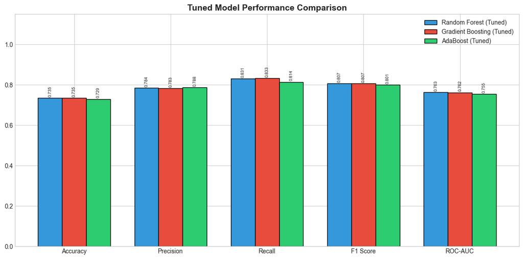

```python
# ── Performance bar chart – tuned models ────────────────────────────
metrics = ['Accuracy','Precision','Recall','F1 Score','ROC-AUC']
fig, ax = plt.subplots(figsize=(12, 6))
x = np.arange(len(metrics))
width = 0.25
for i,(name,color) in enumerate(zip(tuned_df.index,['#3498db','#e74c3c','#2ecc71'])):
    bars = ax.bar(x+(i-1)*width, tuned_df.loc[name,metrics], width,
                  label=name, color=color, edgecolor='black')
    for bar in bars:
        h = bar.get_height()
        ax.text(bar.get_x()+bar.get_width()/2., h+0.005,
                f'{h:.3f}', ha='center', va='bottom', fontsize=7, rotation=90)
ax.set_title('Tuned Model Performance Comparison', fontsize=14, fontweight='bold')
ax.set_xticks(x)
ax.set_xticklabels(metrics)
ax.legend()
ax.set_ylim(0, 1.15)
plt.tight_layout()
plt.show()
```

### ✅ Final Model Selection: Gradient Boosting (Tuned)

**Comparison of All Tuned Models on Test Set:**

[output not shown]

**Conclusion**: Gradient Boosting (Tuned) is deployed as the recommended production model for EasyVisa's visa approval prediction system.

```python
# ── Final model on test set ──────────────────────────────────────────
final_model   = gb_tuned
y_pred_final  = final_model.predict(X_test)
y_proba_final = final_model.predict_proba(X_test)[:,1]

print('=' * 60)
print('FINAL MODEL: Gradient Boosting (Tuned)')
print('=' * 60)
print(classification_report(y_test, y_pred_final, target_names=['Denied','Certified']))
print(f'ROC-AUC: {roc_auc_score(y_test, y_proba_final):.4f}')
```

```
============================================================
FINAL MODEL: Gradient Boosting (Tuned)
============================================================
              precision    recall  f1-score   support

      Denied       0.61      0.54      0.57      1692
   Certified       0.78      0.83      0.81      3404

    accuracy                           0.73      5096
   macro avg       0.70      0.68      0.69      5096
weighted avg       0.73      0.73      0.73      5096

ROC-AUC: 0.7623
```

### Observations – Final Model on Test Data

**Final Model: Gradient Boosting (Tuned)**

- Accuracy: 73.45% | F1: 0.8073 | ROC-AUC: 0.7623

Looking at the classification report breakdown:

- For **Certified** applications (majority class): precision=0.78, recall=0.83 — the model is pretty good at identifying these
- For **Denied** applications (minority class): precision=0.61, recall=0.54 — harder to get right, the model misses about 46% of actual denials

The lower recall on Denied cases means the model tends to lean toward predicting Certified when it's not sure. Whether that's acceptable depends on the business context — for EasyVisa's use case, missing a denial means a client wastes money on a doomed application, so this is something to monitor.

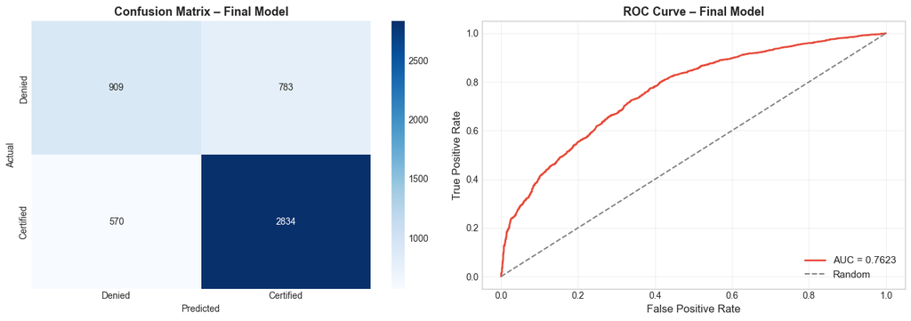

```python
# ── Confusion Matrix + ROC Curve ────────────────────────────────────
fig, axes = plt.subplots(1, 2, figsize=(14, 5))

cm = confusion_matrix(y_test, y_pred_final)
sns.heatmap(cm, annot=True, fmt='d', cmap='Blues', ax=axes[0],
            xticklabels=['Denied','Certified'], yticklabels=['Denied','Certified'])
axes[0].set_title('Confusion Matrix – Final Model', fontsize=13, fontweight='bold')
axes[0].set_ylabel('Actual'); axes[0].set_xlabel('Predicted')

fpr, tpr, _ = roc_curve(y_test, y_proba_final)
axes[1].plot(fpr, tpr, color='#e74c3c', lw=2, label=f'AUC = {auc(fpr,tpr):.4f}')
axes[1].plot([0,1],[0,1], color='gray', linestyle='--', lw=1.5, label='Random')
axes[1].set_xlabel('False Positive Rate', fontsize=12)
axes[1].set_ylabel('True Positive Rate', fontsize=12)
axes[1].set_title('ROC Curve – Final Model', fontsize=13, fontweight='bold')
axes[1].legend(loc='lower right', fontsize=11)
axes[1].grid(True, alpha=0.3)

plt.tight_layout()
plt.show()
```

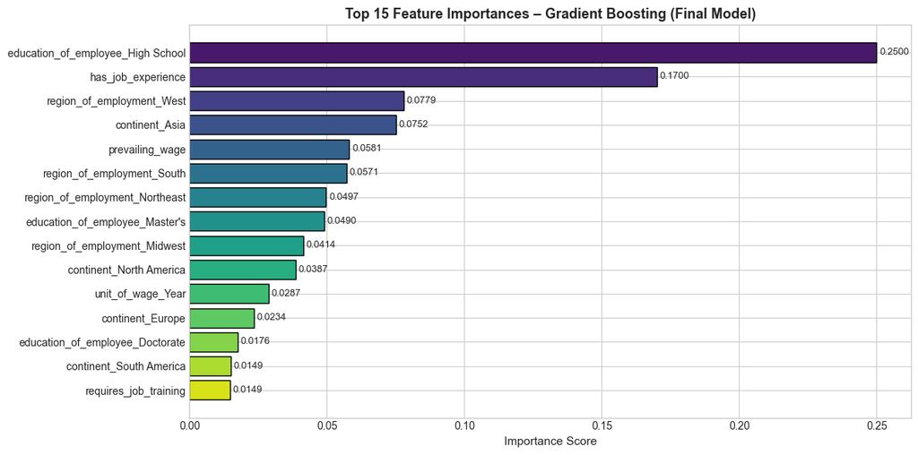

```
Top 10 Features:
                          Feature  Importance
education_of_employee_High School    0.250007
               has_job_experience    0.169955
        region_of_employment_West    0.077949
                   continent_Asia    0.075208
                  prevailing_wage    0.058147
       region_of_employment_South    0.057063
   region_of_employment_Northeast    0.049722
   education_of_employee_Master's    0.048991
     region_of_employment_Midwest    0.041392
          continent_North America    0.038738
```

```python
# ── Feature Importance ───────────────────────────────────────────────
feat_imp = pd.DataFrame({
    'Feature'   : X.columns,
    'Importance': final_model.feature_importances_
}).sort_values('Importance', ascending=False).head(15)

fig, ax = plt.subplots(figsize=(12, 6))
bars = ax.barh(feat_imp['Feature'], feat_imp['Importance'],
               color=sns.color_palette('viridis', len(feat_imp)), edgecolor='black')
ax.set_title('Top 15 Feature Importances – Gradient Boosting (Final Model)',
             fontsize=13, fontweight='bold')
ax.set_xlabel('Importance Score', fontsize=11)
ax.invert_yaxis()
for bar, val in zip(bars, feat_imp['Importance']):
    ax.text(bar.get_width()+0.001, bar.get_y()+bar.get_height()/2,
            f'{val:.4f}', va='center', fontsize=9)
plt.tight_layout()
plt.show()

print('Top 10 Features:')
print(feat_imp.head(10).to_string(index=False))
```

### Observations – Feature Importance

# **Actionable Insights and Recommendations**

## Key Business Insights & Actionable Recommendations

### 📈 Model Performance Summary

[output not shown]

### 💡 Key Business Insights

**2. Education Level Directly Drives Approval** Master's and Doctorate holders are approved at significantly higher rates. OFLC prioritizes high-skill, hard-to-find talent that justifies displacing a local worker. Clients with Bachelor's or lower education should be counseled to strengthen other aspects of their application.

**3. Job Experience is a Meaningful Signal** Applicants with documented prior job experience ('Y') are more likely to be certified. EasyVisa should ensure that work history and specialized skills are thoroughly documented and highlighted in every application.

**4. Company Profile Matters** Newer companies (lower `company_age`) and smaller companies face modestly higher denial rates. Companies under 5 years old should be advised to provide additional financial stability documentation and justification for hiring internationally.

**6. Regional Patterns Exist but are Secondary** The South and Midwest regions have higher application volumes; the Northeast (tech/finance hubs) shows slightly higher approval rates. Regional strategy should be considered when employers have flexibility in the work location designation.

### 🎯 Actionable Recommendations for EasyVisa

**1. Build a Real-Time Pre-Screening Tool** Deploy the Gradient Boosting model as an API-based approval probability calculator. Before a client formally files, they enter their application details and receive an instant probability score. This reduces failed applications and helps EasyVisa prioritize high-probability cases.

**2. Wage Structure Advisory Service** Automatically flag any application where `unit_of_wage = Hour`. Consult with the employer about restructuring compensation to an annual/monthly salary. Where legally feasible, this single change can dramatically increase approval odds.

**3. Education-Based Fast Track** Create a priority consulting lane for Master's and Doctorate applicants. These profiles have the highest approval likelihood and represent the most efficient use of EasyVisa's consulting resources.

**4. Competitive Wage Benchmarking Integration** Integrate Department of Labor (DOL) Occupational Employment Statistics into EasyVisa's portal. Before filing, show employers how their offered wage compares to the prevailing wage for the SOC code — nudging them to offer competitive compensation that strengthens the application.

**6. Continuous Model Retraining Pipeline** Immigration policy and OFLC review criteria evolve. Implement a quarterly retraining schedule with data drift monitoring. Set up automated alerts when model AUC drops below 0.72 to trigger a retraining event.

### 🏆 Conclusion

The **Gradient Boosting (Tuned)** model is recommended as EasyVisa's production prediction engine, achieving:

- **Test Accuracy**: 73.45%
- **F1 Score**: 0.8073
- **ROC-AUC**: 0.7623